# Homework II

Noah Kiefer

2024-11-26

[figure not shown]

## Introduction

This is my solution to task 9 of homework II in the SBD2 module in the autumn semester 2024. In this document I look at three different films and their networks.

## Import Data

I decided on three films, all of which I have already seen in person. Before I started working on the task, I thought I would choose films that I knew, as this could possibly be an advantage for me.

The three films are **[127 hours](https://www.youtube.com/watch?v=OlhLOWTnVoQ)**, **[Spider-Man](https://www.youtube.com/watch?v=t06RUxPbp_c)** and **[Wall-E](https://www.youtube.com/watch?v=CZ1CATNbXg0)**. The data I use was provided by our lecturers on Moodle. I downloaded the .rds files and imported them into R.

## Understand the data

### Summary

Firstly, we look at the summary function of R, which provides important information about the networks. I used this function for all three films.

The first thing I noticed is that they all have the letters UNW in their summary, which means that the networks are undirected, named and weighted.

Next, let’s take a look at the distribution of the nodes. By far the fewest nodes, which in our case means characters in the film that appear in the same scene, is 127 hours (9), followed by Wall-E (34) and Spider-Man (37).

The summary also shows the edges of the three networks. Here, too, it is noticeable that 127 hours (10) has the fewest, followed by Spider-Man (113) and Wall-E (206) has the most.

The summary also indicates that the nodes have the attribute character and the edges are numeric.

```
## [1] "Summary of the film 127 Hours:"
```

```
## [1] "IGRAPH 8fc7011 UNW- 9 10 -- "
## [2] "+ attr: layout (g/n), name (v/c), color (v/c), size (v/n), weight (e/n)"
```

```
## [1] "Summary of the film Spider-Man:"
```

```
## [1] "IGRAPH 3465820 UNW- 37 113 -- "
## [2] "+ attr: layout (g/n), name (v/c), color (v/c), size (v/n), weight (e/n)"
```

```
## [1] "Summary of the film WALL-E:"
```

```
## [1] "IGRAPH 1c360dd UNW- 34 206 -- "
## [2] "+ attr: layout (g/n), name (v/c), color (v/c), size (v/n), weight (e/n)"
```

## Plots

To get a general overview of the various films and their networks, I have presented them in plots. These plots help me to visualise and better understand the data.

### Plot 127 hours

The first network I look at more closely is from the film 127 hours. As already described in the previous chapter Summary, the network has few nodes (9) and edges (10).

If we take a closer look at this network, we notice that the network is weighted. This can be recognised by the partially thicker edges. The main character Aron acts as a **bridge** between the other characters in the film. It is also noticeable that this network has **four pendants** (Pilot, Mom, Rana and Pause).

I think this fruchterman-reingold representation of the network is best suited for this diagram, as it weights the strength of the edges and therefore places nodes closer or further away from other nodes.

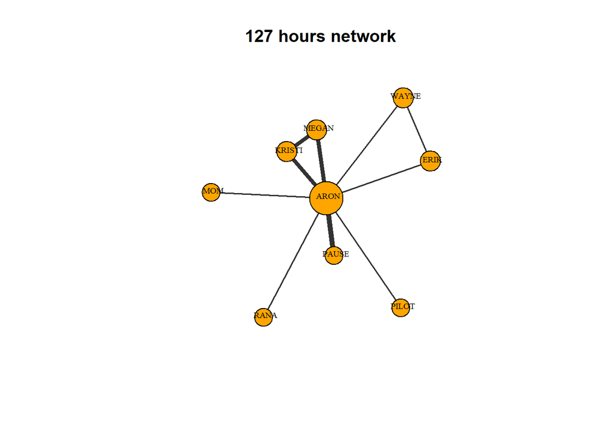

I have also tried to visualise the network in the form of a tree. This is also helpful for a network that does not have many nodes and edges, as it makes it easy to get an overview. In addition, the strength of the edges also shows which nodes have stronger connections.

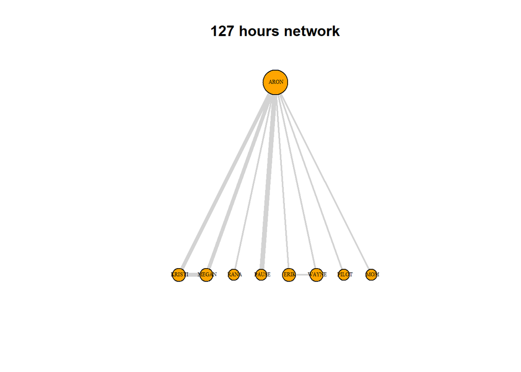

### Plot Spider-Man

The next network I’m watching is from the film Spider-Man. The network is weighted and consists of 37 nodes and 113 edges.

I personally find the circle network the clearest for the film Spider-Man, as the edges and nodes can be easily kept apart and the weighted connections are clearly visible.

[figure not shown]

I have also created a heat map for the network, which clearly shows the weighted connections. The thinner the red, the more often the characters appeared together in the film.

[figure not shown]

### Plot Wall-E

The third network I am looking at is from the film Wall-E. The network is weighted and consists of 34 nodes and 206 edges.

For the Wall-E network, I opted for the star network. This places the main character in the centre and shows the connections. I find this plot clear and it also shows the weighted connections.

[figure not shown]

I also decided in favour of a heat map for the Wall-E network. Here too, the thinner the square, the more often the characters appeared together in the film. The heat map is practical for medium-sized networks, as you can easily read relationships between nodes straight away.

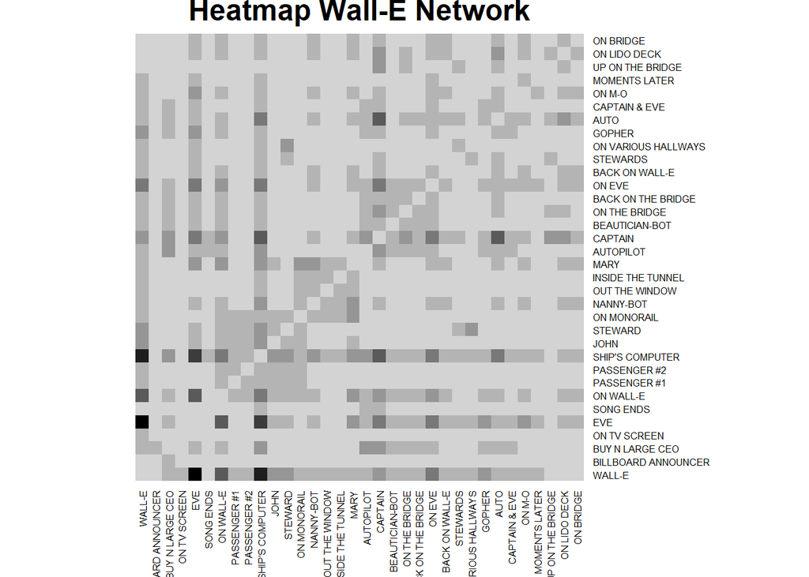

## Insights of the data

Since I have an overview of the different networks of the three films thanks to the plots, I now calculate metrics that tell me more about the network.

### Density

Firstly, I look at the density of the three networks. It is noticeable that the network from the film Wall-E has the highest density with 0.3672, this is also noticeable on the plot, where a high number of edges was visible.

The network of the film 127 hours has the second highest density. This is astonishing, as the number of nodes and edges is significantly smaller than in Spider-Man. The network of 127 hours has a density of 0.2778.

The network of the film Spider-Man has the lowest density. The density is 0.1697, which is astonishing, but when I look at the plot I notice that individual nodes are strongly connected to each other, but there are still many nodes that have few edges.

```
## [1] "The density of the film 127 Hours is: 0.2778"
```

```
## [1] "The density of the film Spider-Man is: 0.1697"
```

```
## [1] "The density of the film WALL-E is: 0.3672"
```

### Assortativity

Next, I looked at the assortativity coefficient in the three networks. This is as follows:

- 127 hours: **-0.7418**
- Spider-Man: **-0.03657**
- Wall-E: **-0.2772**

The assortativity coefficient of a graph is a measure of the extent to which nodes with the same properties connect to each other.

The value of the coefficient varies between -1 and 1. If the value is -1, there is no probability that the two nodes are connected with the same property, but if the value is 1 then it is very likely that the two nodes are connected with the same property.

In our case, this means that **all three films are closer to a disassortative network than to an assortative network**. The film 127 hours is closest to the number -1, but I think this is strongly related to the fact that there are very few edges and nodes in this network.

### Centrality

#### Degree

I also look at metrics that say something about the centrality of a network.

To do this, I first calculate the degree of the individual nodes within the networks. The degree indicates how many edges enter or leave a point, in our case all networks are undirected.

First, we look at the degree of the network 127 hours. As already seen in the plot, the main character Aron has a degree of 8. All other characters in the film have a degree of 1 or 2. Aron is connected to all other nodes in the network.

The second film is Spiderman. Compared to the network of 127 hours, it has many more characters and the distribution is also better. Peter has the highest degree with 21, then 9 characters have a degree between 10 - 14. The remaining 27 characters have a degree between 1 - 9.

The third network we look at is from the film Wall-E. Compared to the other networks, only a few characters here have a degree below 5, three at a time. There are 21 characters with a degree of 10 or more. The character Ship’s Computer has the highest degree with 30, which is very interesting because this network has 34 characters, which means that this node is connected to almost all other characters.

```
## [1] "127 horus:"
```

```
##   RANA  PAUSE  PILOT    MOM KRISTI  MEGAN   ERIK  WAYNE   ARON
##      1      1      1      1      2      2      2      2      8
```

```
## [1] "Spider-Man:"
```

```
##            MAY          GUARD     BANK GUARD         CABBIE         COP #2
##              1              1              1              1              1
##            MAN         COP #1            COP          WOMAN     FEMALE COP
##              1              2              2              2              2
##            BEN  CHIEF SURGEON       BRAINMAN     SURGEON #2     HEAD NURSE
##              3              4              4              4              4
## RING ANNOUNCER       OLD LADY        HIPSTER            REF      DETECTIVE
##              4              4              4              4              4
##         DOCTOR        JAMESON    YOUNG WOMAN       AUNT MAY        CRUSHER
##              4              6              6              7              7
##          REISS            KIM            ROZ        THORKEL            OCK
##              8              9             10             10             11
##          FLASH         WEINER          HARRY          NURSE            LIZ
##             11             12             12             12             13
##     SPIDER-MAN          PETER
##             14             21
```

```
## [1] "Wall-E:"
```

```
## BILLBOARD ANNOUNCER        ON TV SCREEN           SONG ENDS ON VARIOUS HALLWAYS
##                   1                   1                   3                   5
##       MOMENTS LATER    UP ON THE BRIDGE      OUT THE WINDOW   INSIDE THE TUNNEL
##                   5                   5                   6                   6
##        PASSENGER #1        PASSENGER #2            STEWARDS                JOHN
##                   7                   7                   8                   9
##       CAPTAIN & EVE             STEWARD      BEAUTICIAN-BOT              GOPHER
##                   9                  10                  10                  10
##         ON MONORAIL  BACK ON THE BRIDGE           ON BRIDGE      BACK ON WALL-E
##                  11                  11                  11                  12
##       ON THE BRIDGE              ON M-O        ON LIDO DECK     BUY N LARGE CEO
##                  13                  13                  13                  14
##           AUTOPILOT           NANNY-BOT                MARY              ON EVE
##                  14                  15                  16                  20
##                AUTO             CAPTAIN           ON WALL-E                 EVE
##                  20                  22                  23                  24
##              WALL-E     SHIP'S COMPUTER
##                  28                  30
```

#### Betweenness

The betweenness of a network indicates how many flows pass between a particular node.

In the film 127 hours, the betweenness of Aron is 26, all other characters have 0, which means that all flows pass through one node, namely Aron. This node is a gatekeeper in this network.

In the Spider-Man network, Peter’s betweenness is the highest at 206.9471. In this network there are also characters with the value 0 in total 11.

In the network of the film Wall-E, only the two pendents I described earlier have a value of 0. The remaining characters have a betweenness value between 0.4095 - 88.7130, the character with the highest value is Wall-E.

I noticed here that the film Spider Man has a high number of flows, as the degree of betweenness is significantly higher than in the other films. Although Wall-E has more Edges, the film has less high Betweenness values than Spider-Man.

#### Closeness

In analyzing the Closeness Centrality of the networks, this metric indicates how central a particular node is. The values are scaled between 0 and 1, with higher values representing greater centrality.

In the network of the film 127 Hours, Aron has the highest Closeness Centrality with a value of 0.4444, as he is the main character and has many connections to others. The lowest value is held by the character Pause, with 0.1509.

In the Spider-Man network, Peter has the highest Closeness Centrality with a value of 0.5143. The lowest value is attributed to the character Cop #2, with 0.1885.

For the film WALL-E, the character WALL-E holds the highest value at 0.7174. The lowest value belongs to Billboard Announcer, with 0.3750. Interestingly, most characters in this network have relatively high centrality values compared to the other films. I believe this is due to the high density of this network.

### Locale measures

#### Communities

I have analysed the three networks for communities. The definition of a community is: **highly connected subsets of nodes**.

The networks 127 hours and Wall-E only have one community with all the characters. Spiderman, on the other hand, has six different communities. The largest has 18 members and the smallest 2.

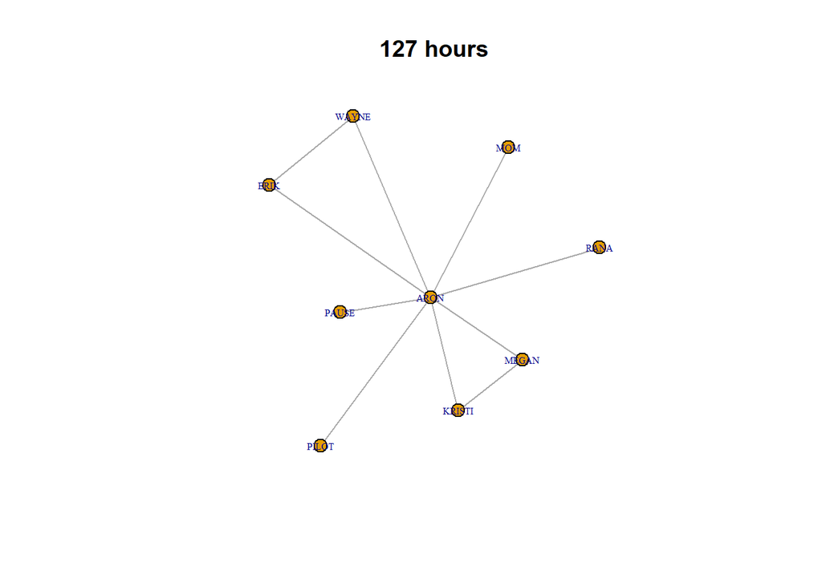

[figure not shown]

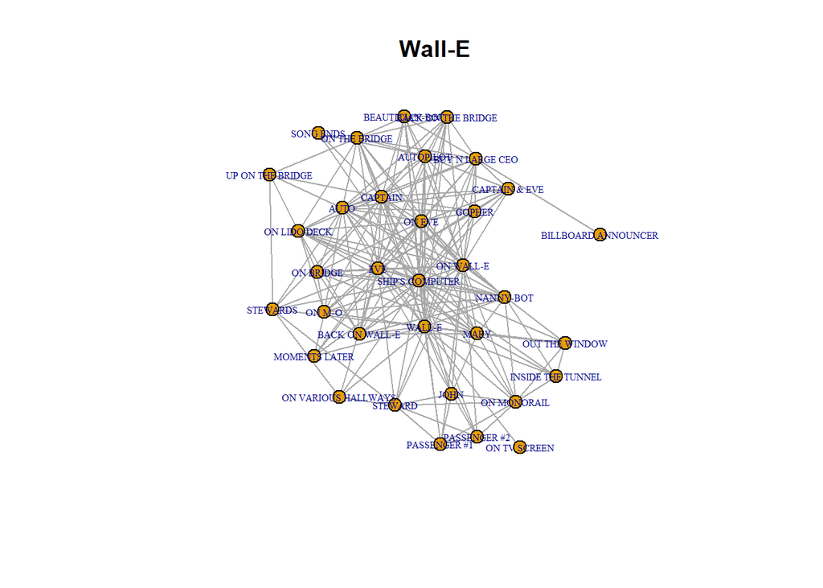

#### Cliques

I also analyse cliques in the three networks. The definition of a clique is **subset of nodes in an undirected graph whose induced subgraph is complete**.

It is noticeable that Wall-E has the largest clique with 12 nodes, followed by Spider-Man’s network with three cliques that all have 8 nodes and 127 hours has two with three nodes each.

```
## [1] "largest clique in 127 horus:"
```

```
## [[1]]
## + 3/9 vertices, named, from 8fc7011:
## [1] ARON  WAYNE ERIK
##
## [[2]]
## + 3/9 vertices, named, from 8fc7011:
## [1] ARON   KRISTI MEGAN
```

```
## [1] "largest clique in Spider-Man:"
```

```
## [[1]]
## + 8/37 vertices, named, from 3465820:
## [1] KIM     WEINER  THORKEL ROZ     FLASH   HARRY   PETER   LIZ
##
## [[2]]
## + 8/37 vertices, named, from 3465820:
## [1] THORKEL WEINER  ROZ     FLASH   HARRY   PETER   LIZ     OCK
##
## [[3]]
## + 8/37 vertices, named, from 3465820:
## [1] ROZ        WEINER     SPIDER-MAN FLASH      HARRY      PETER      LIZ
## [8] OCK
```

```
## [1] "largest clique in Wall-E:"
```

```
## [[1]]
## + 12/34 vertices, named, from 1c360dd:
##  [1] ON BRIDGE       EVE             ON LIDO DECK    ON M-O
##  [5] AUTO            BACK ON WALL-E  ON EVE          CAPTAIN
##  [9] MARY            NANNY-BOT       SHIP'S COMPUTER ON WALL-E
```

## Conclusion

The three networks analysed in the self-selected films - 127 Hours (biographical drama), Spider-Man (superhero action) and Wall-E (animated science fiction film) - have different film adaptations, which are reflected in their social networks.

I used methods to examine the interactions between the characters in the films that we discussed in class. Metrics such as density, centrality (degree, betweenness, closeness), assortativity and cliques provided insights into the characteristics of the networks. For visualisation, I used different plots and heatmaps that highlighted the relationships and connections between the characters in each network.

Main differences:

- Size: Wall-E had the highest density **(0.3672)** and the largest clique **(12 nodes)**, indicating a dense network, while 127 Hours with only 9 nodes reflects the focus on a single character (Aron).
- Centrality: Wall-E’s main character has strong centrality values, while Spider-Man spread the importance across multiple characters, reflecting its ensemble cast.
- Communities: Spider-Man is characterised by six distinct communities, as opposed to the single-community networks in 127 Hours and Wall-E.

Similarities:

- All networks were undirected, named and weighted.
- All nodes within the networks have at least one connection.

Overall, the analysis shows how the network structures reflect the narrative complexity of each film. 127 Hours emphasises a solitary battle, Spider-Man shows a web of character interactions, and Wall-E connects a compact network. These findings emphasise the value of network analysis in uncovering nuances in the narrative.